# Avaliação técnica — Quaest, Data Scientist Jr.

# Sumário apenas das atividades

1. Atividade 1 - Função para tabela de contingência
2. .  
   2.1. Atividade 2 - Item 2.1) Gráfico para a variável intenção de voto  
   2.2. Atividade 2.2) Plot e perguntas - aval_gov x voto1

# Sumário da análise completa

1. Importanto bilbiotecas
2. Funções úteis  
   2.1. Atividade 1 - Função para tabela de contingência  
   2.2. Outras funções úteis
3. Análise preliminar
4. Análise univariada  
   4.1. Atividade 2 - Item 2.1) Gráfico para a variável intenção de voto  
   4.2. Variável "sexo"  
   4.3. Variável "rendaf"  
   4.4. Variável "esc"  
   4.5. Variável "aval_gov"  
   4.6. Variável numérica "idade"
5. Análise bivariada  
   5.1. Atividade 2.2) Plot e perguntas - aval_gov x voto1  
   5.2. sexo x voto1  
   5.3. idade (categorizada) x voto1  
   5.4. rendaf x voto1  
   5.5. esc x voto1

# Resumo da Análise

# 1. Importando bibliotecas

```python
import pandas as pd
import numpy as np
import matplotlib.pyplot as plt
import seaborn as sns
```

# 2. Funções úteis

## 2.1. Atividade 1 - Função para tabela de contingência

Enunciado:

- Crie uma função em alguma linguagem de programação, preferencialmente em R ou Python, que automatize a construção de tabelas de contingência (parte 1). O objetivo é identificar se há uma diferença sociodemográfica na intenção de voto. Em outras palavras, por ex.: As mulheres e os homens estão votando no mesmo candidato? (parte 2 - virá na análise bivariada)

```python
# pip install tabulate - Instalar se já não tiver para rodar as funções abaixo. Não precisa chamar biblioteca, basta instalar
def tabcont_1var(df, column):
    '''
    Tabela de frequência para 1 variável apenas. Utilizada em análise univariada
    O output são 2 tabelas, uma com valores absolutos e a outra com a % na coluna, sendo o total da coluna = 1
    Variáveis necessárias: df = dataframe, column = coluna
    '''
    print('Valores absolutos')
    print(df[column].value_counts(dropna=False).to_markdown())
    print('\n')
    print('Proporção')
    print((df[column].value_counts(dropna=False)/len(df)*100).to_markdown())

def tabcont_2var(column1, column2):
    '''
    Tabela de contingência para analisar 2 variáveis.
    O output são 3 tabelas, uma com valores absolutos, outra com % na linha, sendo o total da linha = 1
    e outra com % na coluna, sendo o total da coluna = 1.
    Variáveis necessárias: column1 = coluna 1, column2 = coluna 2
    '''
    tabcont_pl = pd.crosstab(index=column1, columns=column2, margins=True)
    print('Valores absolutos:\n')
    print(tabcont_pl.to_markdown())
    print('\nPorcentagem na linha:\n')
    print(round(tabcont_pl.div(tabcont_pl['All'], axis=0),2).to_markdown())
    print('\nPorcentagem na coluna:\n')
    print(round(tabcont_pl.div(tabcont_pl.loc['All'], axis=1),2).to_markdown())
```

## 2.2 Outras funções úteis

A primeira é para plotar um boxplot e um histograma de uma variável

A segunda é para calcular os limites de outliers

```python
def plot_hist_box(column, bins):
    '''
    Plota um histograma e um boxplot de uma variável numérica
    '''
    fig, axs = plt.subplots(1, 2, tight_layout=True, figsize=(10,4));
    axs[0].hist(column, bins=bins);
    axs[1].boxplot(column);


def outlier_bounds(column):
    '''
    Calcula os limites inferior e superior para outliers
    '''

    q1, q3 = np.percentile(column, [25,75])
    iqr = q3 - q1
    lower_bound = q1 -(1.5 * iqr)
    upper_bound = q3 +(1.5 * iqr)
    return print(' Lower bound =', lower_bound,'\n', 'Upper bound =', upper_bound)
```

# 3. Análise preliminar

## 3.1. Leitura do banco de dados

df = dataframe

```python
df = pd.read_excel('bd_surveyquaest.xlsx', sheet_name = 'Sheet 1')
df
```

|  | sbjnum | sexo | idade | rendaf | esc | aval_gov | voto1 |
| --- | --- | --- | --- | --- | --- | --- | --- |
| 0 | 136037235 | Masculino | 57 | De R$ 2.091,00 a R$ 3.135,00 (+ de 2SM até 3 SM) | Ensino médio completo | Regular positiva | Candidato 2 |
| 1 | 136037575 | Masculino | 32 | De R$ 2.091,00 a R$ 3.135,00 (+ de 2SM até 3 SM) | Ensino médio completo | Boa | Ninguém/Branco/Nulo |
| 2 | 136038074 | Masculino | 70 | De R$ 5.226,00 a R$ 10.450,00 (+ de 5SM até 10... | Ensino médio completo | Boa | Candidato 2 |
| 3 | 136041069 | Masculino | 50 | De R$ 2.091,00 a R$ 3.135,00 (+ de 2SM até 3 SM) | Ensino fundamental incompleto | Ótima | Candidato 2 |
| 4 | 136041107 | Masculino | 24 | De R$ 3.136,00 a R$ 5.225,00 (+ de 3SM até 5 SM) | Ensino superior incompleto | Boa | Candidato 2 |
| ... | ... | ... | ... | ... | ... | ... | ... |
| 995 | 136140712 | Feminino | 20 | De R$ 5.226,00 a R$ 10.450,00 (+ de 5SM até 10... | Ensino médio completo | Boa | Candidato 2 |
| 996 | 136140811 | Feminino | 18 | De R$ 2.091,00 a R$ 3.135,00 (+ de 2SM até 3 SM) | Ensino médio incompleto | Ótima | Candidato 14 |
| 997 | 136140955 | Feminino | 22 | De R$ 2.091,00 a R$ 3.135,00 (+ de 2SM até 3 SM) | Ensino médio completo | Regular positiva | Ninguém/Branco/Nulo |
| 998 | 136141043 | Feminino | 45 | De R$ 2.091,00 a R$ 3.135,00 (+ de 2SM até 3 SM) | Ensino superior incompleto | Ótima | Candidato 2 |
| 999 | 136141106 | Feminino | 18 | De R$ 2.091,00 a R$ 3.135,00 (+ de 2SM até 3 SM) | Ensino médio completo | Regular negativa | NS/NR |

1000 rows × 7 columns

## 3.2. Procurando por células vazias

```python
df.isnull().sum()
```

```
sbjnum      0
sexo        0
idade       0
rendaf      0
esc         0
aval_gov    0
voto1       0
dtype: int64
```

Não há células vazias, banco 100% preenchido

## 3.3. Checando as colunas categóricas em busca de erros e categorias repetidas

```python
print(df['sexo'].unique())
print('\n')
print(df['rendaf'].unique())
print('\n')
print(df['esc'].unique())
print('\n')
print(df['aval_gov'].unique())
print('\n')
print(df['voto1'].unique())
```

```
['Masculino' 'Feminino']


['De R$ 2.091,00 a R$ 3.135,00 (+ de 2SM até 3 SM)'
 'De R$ 5.226,00 a R$ 10.450,00 (+ de 5SM até 10 SM)'
 'De R$ 3.136,00 a R$ 5.225,00 (+ de 3SM até 5 SM)'
 'De R$ 1.046,00 a R$ 2.090,00 (+ de 1SM até 2 SM)'
 'Até R$ 1.045,00 (até 1 SM)'
 'De R$ 15.676,00 a R$ 20.900,00 (+ de 15SM até 20 SM)'
 'De R$ 10.451,00 a R$ 15.675,00 (+ de 10SM até 15 SM)'
 'Mais de R$ 20.900,00 (+ de 20 SM)']


['Ensino médio completo' 'Ensino fundamental incompleto'
 'Ensino superior incompleto' 'Ensino superior completo'
 'Sem instrução e menos de 1 ano de estudo' 'Ensino médio incompleto'
 'Ensino fundamental completo']


['Regular positiva' 'Boa' 'Ótima' 'Péssima' 'Ruim' 'Regular negativa'
 'NS/NR']


['Candidato 2' 'Ninguém/Branco/Nulo' 'Candidato 1' 'NS/NR' 'Candidato 3'
 'Candidato 4' 'Candidato 5' 'Candidato 6' 'Candidato 7' 'Candidato 8'
 'Candidato 9' 'Candidato 10' 'Candidato 11' 'Candidato 12' 'Candidato 13'
 'Candidato 14']
```

Não há erros nas categorias, tudo certo!

Obs: NS/NR = Não sabe/Não responde

# 4. Análise univariada

## 4.1. Atividade 2 - Item 2.1) Gráfico para a variável intenção de voto

Enunciado:

Ainda com essa base de dados, construa dois gráficos.

2.1) O primeiro gráfico será da variável intenção de voto.

```python
tabcont_1var(df, 'voto1')
```

```
Valores absolutos
|                     |   voto1 |
|:--------------------|--------:|
| Candidato 2         |     523 |
| Ninguém/Branco/Nulo |     142 |
| NS/NR               |     140 |
| Candidato 1         |      42 |
| Candidato 8         |      26 |
| Candidato 5         |      25 |
| Candidato 10        |      20 |
| Candidato 9         |      19 |
| Candidato 3         |      16 |
| Candidato 4         |      12 |
| Candidato 6         |      10 |
| Candidato 7         |       7 |
| Candidato 14        |       6 |
| Candidato 12        |       6 |
| Candidato 13        |       3 |
| Candidato 11        |       3 |


Proporção
|                     |   voto1 |
|:--------------------|--------:|
| Candidato 2         |    52.3 |
| Ninguém/Branco/Nulo |    14.2 |
| NS/NR               |    14   |
| Candidato 1         |     4.2 |
| Candidato 8         |     2.6 |
| Candidato 5         |     2.5 |
| Candidato 10        |     2   |
| Candidato 9         |     1.9 |
| Candidato 3         |     1.6 |
| Candidato 4         |     1.2 |
| Candidato 6         |     1   |
| Candidato 7         |     0.7 |
| Candidato 14        |     0.6 |
| Candidato 12        |     0.6 |
| Candidato 13        |     0.3 |
| Candidato 11        |     0.3 |
```

Por se tratar de uma variável categórica, pode-se utilizar um gráfico de barras para representá-la, mais especificamente, countplot com a biblioteca seaborn.

O gráfico será ordenado POR CANDIDATO. Pode-se observar que o candidato 2 tem a maior intenção de voto, seguido dos votos nulos/brancos.

```python
# Ao testar a rotação do eixo X, a categoria "Ninguém/Branco/Nulo" apresentava um bug em que ficava
# fora da posição correta por ser muito grande.
# O código abaixo substitui os valores de "Ninguém/Branco/Nulo" por "Branco/Nulo" para corrigir o problema
df['voto1'] = df['voto1'].replace("Ninguém/Branco/Nulo", "Branco/Nulo")
```

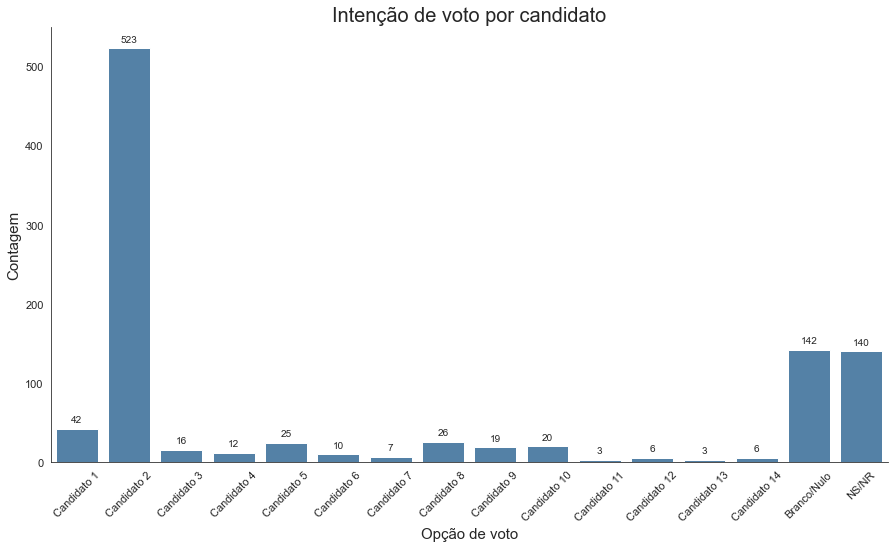

```python
# estilo white do seaborn
sns.set_style('white')

# Ordem alfabética
ordem = ["Candidato 1", "Candidato 2", "Candidato 3", "Candidato 4", "Candidato 5", "Candidato 6", "Candidato 7", "Candidato 8",
"Candidato 9", "Candidato 10", "Candidato 11", "Candidato 12", "Candidato 13", "Candidato 14", "Branco/Nulo", "NS/NR"]

plt.figure(figsize = (15,8))
ax = sns.countplot(x = "voto1", data = df, color = 'steelblue', order = ordem)
title = ax.axes.set_title('Intenção de voto por candidato',fontsize = 20) # Título e tamanho
x_labels = ax.set_xticklabels(rotation=45, labels = ax.get_xticklabels()) # possível utilizar também: labels = df['voto1'].unique()
x_axis_name = ax.set_xlabel('Opção de voto', fontsize=15) # Nome eixo x e tamanho
y_axis_name = ax.set_ylabel('Contagem', fontsize=15) # Nome eixo y e tamanho
axis_num_size = ax.tick_params(labelsize=11) # ajuste do tamanho dos valores dos eixos

# O código abaixo para colocar os números nas barras foi retirado e adaptado de:
#https://medium.com/swlh/quick-guide-to-labelling-data-for-common-seaborn-plots-736e10bf14a9

for p in ax.patches:
    # determina a altura de cada barra
    altura = p.get_height()
    # adiciona o texto em cada barra
    ax.text(x = p.get_x()+(p.get_width()/2), # posição x de cada número. ficará no centro.
    y = altura+8, # posição y do número, 8 unidades acima da barra
    s = '{:.0f}'.format(altura), # formatação para número inteiro
    ha = 'center') # alinhamento horizontal no centro

sns.despine() # remover o contorno
```

Observações a partir da tabela e do gráfico:

- 52% da base votou no candidato 2, 14,2% votaram nulo e 14% não se lembram ou não sabem do voto. Os outros candidatos receberam, somados, apenas 19,5% dos votos

## 4.2. Variável "sexo"

```python
tabcont_1var(df, 'sexo')
```

```
Valores absolutos
|           |   sexo |
|:----------|-------:|
| Feminino  |    545 |
| Masculino |    455 |


Proporção
|           |   sexo |
|:----------|-------:|
| Feminino  |   54.5 |
| Masculino |   45.5 |
```

Observações

- Base com 90 mulheres a mais que homens

## 4.3. Variável "rendaf"

```python
tabcont_1var(df, 'rendaf')
```

```
Valores absolutos
|                                                      |   rendaf |
|:-----------------------------------------------------|---------:|
| De R$ 1.046,00 a R$ 2.090,00 (+ de 1SM até 2 SM)     |      246 |
| De R$ 2.091,00 a R$ 3.135,00 (+ de 2SM até 3 SM)     |      210 |
| Até R$ 1.045,00 (até 1 SM)                           |      205 |
| De R$ 3.136,00 a R$ 5.225,00 (+ de 3SM até 5 SM)     |      177 |
| De R$ 5.226,00 a R$ 10.450,00 (+ de 5SM até 10 SM)   |      110 |
| De R$ 10.451,00 a R$ 15.675,00 (+ de 10SM até 15 SM) |       28 |
| De R$ 15.676,00 a R$ 20.900,00 (+ de 15SM até 20 SM) |       17 |
| Mais de R$ 20.900,00 (+ de 20 SM)                    |        7 |


Proporção
|                                                      |   rendaf |
|:-----------------------------------------------------|---------:|
| De R$ 1.046,00 a R$ 2.090,00 (+ de 1SM até 2 SM)     |     24.6 |
| De R$ 2.091,00 a R$ 3.135,00 (+ de 2SM até 3 SM)     |     21   |
| Até R$ 1.045,00 (até 1 SM)                           |     20.5 |
| De R$ 3.136,00 a R$ 5.225,00 (+ de 3SM até 5 SM)     |     17.7 |
| De R$ 5.226,00 a R$ 10.450,00 (+ de 5SM até 10 SM)   |     11   |
| De R$ 10.451,00 a R$ 15.675,00 (+ de 10SM até 15 SM) |      2.8 |
| De R$ 15.676,00 a R$ 20.900,00 (+ de 15SM até 20 SM) |      1.7 |
| Mais de R$ 20.900,00 (+ de 20 SM)                    |      0.7 |
```

Observações

- 66,1% da base tem renda entre 0 e 3 salários mínimos, isso representa 661 pessoas;
- 17,7% da base recebe entre 3 e 5 salários mínimos;
- 15,5% da base recebe entre 5 e 20 salários mínimos e
- 0,7% da base recebe mais de 20 salários mínimos

## 4.4. Variável "esc"

```python
tabcont_1var(df, 'esc')
```

```
Valores absolutos
|                                          |   esc |
|:-----------------------------------------|------:|
| Ensino médio completo                    |   326 |
| Ensino superior completo                 |   195 |
| Ensino fundamental incompleto            |   184 |
| Ensino superior incompleto               |   105 |
| Ensino médio incompleto                  |    89 |
| Ensino fundamental completo              |    84 |
| Sem instrução e menos de 1 ano de estudo |    17 |


Proporção
|                                          |   esc |
|:-----------------------------------------|------:|
| Ensino médio completo                    |  32.6 |
| Ensino superior completo                 |  19.5 |
| Ensino fundamental incompleto            |  18.4 |
| Ensino superior incompleto               |  10.5 |
| Ensino médio incompleto                  |   8.9 |
| Ensino fundamental completo              |   8.4 |
| Sem instrução e menos de 1 ano de estudo |   1.7 |
```

## 4.5. Variável "aval_gov"

```python
tabcont_1var(df, 'aval_gov')
```

```
Valores absolutos
|                  |   aval_gov |
|:-----------------|-----------:|
| Boa              |        443 |
| Ótima            |        181 |
| Regular positiva |        175 |
| Regular negativa |         74 |
| Péssima          |         64 |
| Ruim             |         49 |
| NS/NR            |         14 |


Proporção
|                  |   aval_gov |
|:-----------------|-----------:|
| Boa              |       44.3 |
| Ótima            |       18.1 |
| Regular positiva |       17.5 |
| Regular negativa |        7.4 |
| Péssima          |        6.4 |
| Ruim             |        4.9 |
| NS/NR            |        1.4 |
```

Observações:

- 79,9% da base avalia o governo de forma positiva
- 18,7% avalia de forma negativa
- 1,4% não sabe ou não respondeu a questão

## 4.6. Variável numérica "idade"

```python
df['idade'].describe()
```

```
count    1000.000000
mean       44.286000
std        16.277874
min        17.000000
25%        30.000000
50%        43.000000
75%        58.000000
max        86.000000
Name: idade, dtype: float64
```

Verificação dos intervalos de outliers

```python
outlier_bounds(df['idade'])
```

```
 Lower bound = -12.0
 Upper bound = 100.0
```

Histograma e boxplot

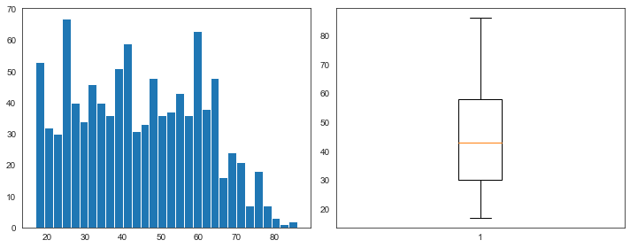

```python
plot_hist_box(df['idade'], 30)
```

Observações:

- 25% da base tem idade entre 17 e 30 anos, 50% da base apresenta idade até 43 anos, 25% da base tem idade entre 58 e 86 anos.
- Idade máxima de 86 anos e menor de 17
- Média > mediana, distribuição é assimétrica a direita
- Não há outliers

# 5. Análise bivariada

## 5.1. Atividade 2.2) Plot e perguntas - aval_gov x voto1

Enunciado:

2.2) Já o segundo, plot um gráfico que represente o cruzamento entre as variáveis intenção de voto e avaliação do governo. Quem avalia o governo de forma positiva, vota em qual candidato? E quem avalia de forma negativa?

A tabela abaixo traz o cruzamento entre a intenção de voto e a avaliação do governo, Podemos ver que fica mais difícil de se avaliar a tabela quando se tem graus de positividade, portanto, **como estamos interessados apenas nas avaliações positivas e negativas, vide enunciado, o grau da positividade e negatividade não são relevantes**, assim, vou transformar tudo o que tiver caráter positivo em "Positiva" e tudo de caráter negativo em "Negativa". O que for NS/NR será mantido. Esse resultado virá em uma nova coluna.

```python
tabcont_2var(df['voto1'], df['aval_gov'])
```

```
Valores absolutos:

| voto1        |   Boa |   NS/NR |   Péssima |   Regular negativa |   Regular positiva |   Ruim |   Ótima |   All |
|:-------------|------:|--------:|----------:|-------------------:|-------------------:|-------:|--------:|------:|
| Branco/Nulo  |    36 |       5 |        25 |                 20 |                 35 |     13 |       8 |   142 |
| Candidato 1  |    14 |       0 |         5 |                  7 |                 10 |      3 |       3 |    42 |
| Candidato 10 |     6 |       0 |         2 |                  1 |                  8 |      1 |       2 |    20 |
| Candidato 11 |     0 |       0 |         1 |                  0 |                  0 |      1 |       1 |     3 |
| Candidato 12 |     2 |       0 |         1 |                  0 |                  1 |      0 |       2 |     6 |
| Candidato 13 |     1 |       0 |         0 |                  1 |                  0 |      0 |       1 |     3 |
| Candidato 14 |     2 |       0 |         1 |                  1 |                  1 |      0 |       1 |     6 |
| Candidato 2  |   300 |       1 |         1 |                  7 |                 59 |      1 |     154 |   523 |
| Candidato 3  |     8 |       0 |         0 |                  4 |                  2 |      2 |       0 |    16 |
| Candidato 4  |     6 |       0 |         0 |                  2 |                  4 |      0 |       0 |    12 |
| Candidato 5  |    11 |       0 |         1 |                  7 |                  4 |      2 |       0 |    25 |
| Candidato 6  |     4 |       0 |         1 |                  3 |                  2 |      0 |       0 |    10 |
| Candidato 7  |     1 |       0 |         1 |                  2 |                  2 |      1 |       0 |     7 |
| Candidato 8  |     2 |       0 |         7 |                  5 |                  5 |      4 |       3 |    26 |
| Candidato 9  |     7 |       0 |         1 |                  1 |                  6 |      3 |       1 |    19 |
| NS/NR        |    43 |       8 |        17 |                 13 |                 36 |     18 |       5 |   140 |
| All          |   443 |      14 |        64 |                 74 |                175 |     49 |     181 |  1000 |

Porcentagem na linha:

| voto1        |   Boa |   NS/NR |   Péssima |   Regular negativa |   Regular positiva |   Ruim |   Ótima |   All |
|:-------------|------:|--------:|----------:|-------------------:|-------------------:|-------:|--------:|------:|
| Branco/Nulo  |  0.25 |    0.04 |      0.18 |               0.14 |               0.25 |   0.09 |    0.06 |     1 |
| Candidato 1  |  0.33 |    0    |      0.12 |               0.17 |               0.24 |   0.07 |    0.07 |     1 |
| Candidato 10 |  0.3  |    0    |      0.1  |               0.05 |               0.4  |   0.05 |    0.1  |     1 |
| Candidato 11 |  0    |    0    |      0.33 |               0    |               0    |   0.33 |    0.33 |     1 |
| Candidato 12 |  0.33 |    0    |      0.17 |               0    |               0.17 |   0    |    0.33 |     1 |
| Candidato 13 |  0.33 |    0    |      0    |               0.33 |               0    |   0    |    0.33 |     1 |
| Candidato 14 |  0.33 |    0    |      0.17 |               0.17 |               0.17 |   0    |    0.17 |     1 |
| Candidato 2  |  0.57 |    0    |      0    |               0.01 |               0.11 |   0    |    0.29 |     1 |
| Candidato 3  |  0.5  |    0    |      0    |               0.25 |               0.12 |   0.12 |    0    |     1 |
| Candidato 4  |  0.5  |    0    |      0    |               0.17 |               0.33 |   0    |    0    |     1 |
| Candidato 5  |  0.44 |    0    |      0.04 |               0.28 |               0.16 |   0.08 |    0    |     1 |
| Candidato 6  |  0.4  |    0    |      0.1  |               0.3  |               0.2  |   0    |    0    |     1 |
| Candidato 7  |  0.14 |    0    |      0.14 |               0.29 |               0.29 |   0.14 |    0    |     1 |
| Candidato 8  |  0.08 |    0    |      0.27 |               0.19 |               0.19 |   0.15 |    0.12 |     1 |
```

[output cut: 10 more lines]

```
| Candidato 10 |  0.01 |    0    |      0.03 |               0.01 |               0.05 |   0.02 |    0.01 |  0.02 |
| Candidato 11 |  0    |    0    |      0.02 |               0    |               0    |   0.02 |    0.01 |  0    |
| Candidato 12 |  0    |    0    |      0.02 |               0    |               0.01 |   0    |    0.01 |  0.01 |
| Candidato 13 |  0    |    0    |      0    |               0.01 |               0    |   0    |    0.01 |  0    |
| Candidato 14 |  0    |    0    |      0.02 |               0.01 |               0.01 |   0    |    0.01 |  0.01 |
| Candidato 2  |  0.68 |    0.07 |      0.02 |               0.09 |               0.34 |   0.02 |    0.85 |  0.52 |
| Candidato 3  |  0.02 |    0    |      0    |               0.05 |               0.01 |   0.04 |    0    |  0.02 |
| Candidato 4  |  0.01 |    0    |      0    |               0.03 |               0.02 |   0    |    0    |  0.01 |
| Candidato 5  |  0.02 |    0    |      0.02 |               0.09 |               0.02 |   0.04 |    0    |  0.02 |
| Candidato 6  |  0.01 |    0    |      0.02 |               0.04 |               0.01 |   0    |    0    |  0.01 |
| Candidato 7  |  0    |    0    |      0.02 |               0.03 |               0.01 |   0.02 |    0    |  0.01 |
| Candidato 8  |  0    |    0    |      0.11 |               0.07 |               0.03 |   0.08 |    0.02 |  0.03 |
| Candidato 9  |  0.02 |    0    |      0.02 |               0.01 |               0.03 |   0.06 |    0.01 |  0.02 |
| NS/NR        |  0.1  |    0.57 |      0.27 |               0.18 |               0.21 |   0.37 |    0.03 |  0.14 |
| All          |  1    |    1    |      1    |               1    |               1    |   1    |    1    |  1    |
```

Transformação da aval_gov em aval_gov_resumido

```python
df['aval_gov_resumido'] = df['aval_gov']
df['aval_gov_resumido'] = df['aval_gov_resumido'].replace(['Boa', 'Regular positiva', 'Ótima'], 'Positiva')
df['aval_gov_resumido'] = df['aval_gov_resumido'].replace(['Ruim', 'Regular negativa', 'Péssima'], 'Negativa')

df['aval_gov_resumido'].value_counts()
```

```
Positiva    799
Negativa    187
NS/NR        14
Name: aval_gov_resumido, dtype: int64
```

Montando a tabela de contingência novamente

```python
tabcont_2var(df['voto1'], df['aval_gov_resumido'])
```

```
Valores absolutos:

| voto1        |   NS/NR |   Negativa |   Positiva |   All |
|:-------------|--------:|-----------:|-----------:|------:|
| Branco/Nulo  |       5 |         58 |         79 |   142 |
| Candidato 1  |       0 |         15 |         27 |    42 |
| Candidato 10 |       0 |          4 |         16 |    20 |
| Candidato 11 |       0 |          2 |          1 |     3 |
| Candidato 12 |       0 |          1 |          5 |     6 |
| Candidato 13 |       0 |          1 |          2 |     3 |
| Candidato 14 |       0 |          2 |          4 |     6 |
| Candidato 2  |       1 |          9 |        513 |   523 |
| Candidato 3  |       0 |          6 |         10 |    16 |
| Candidato 4  |       0 |          2 |         10 |    12 |
| Candidato 5  |       0 |         10 |         15 |    25 |
| Candidato 6  |       0 |          4 |          6 |    10 |
| Candidato 7  |       0 |          4 |          3 |     7 |
| Candidato 8  |       0 |         16 |         10 |    26 |
| Candidato 9  |       0 |          5 |         14 |    19 |
| NS/NR        |       8 |         48 |         84 |   140 |
| All          |      14 |        187 |        799 |  1000 |

Porcentagem na linha:

| voto1        |   NS/NR |   Negativa |   Positiva |   All |
|:-------------|--------:|-----------:|-----------:|------:|
| Branco/Nulo  |    0.04 |       0.41 |       0.56 |     1 |
| Candidato 1  |    0    |       0.36 |       0.64 |     1 |
| Candidato 10 |    0    |       0.2  |       0.8  |     1 |
| Candidato 11 |    0    |       0.67 |       0.33 |     1 |
| Candidato 12 |    0    |       0.17 |       0.83 |     1 |
| Candidato 13 |    0    |       0.33 |       0.67 |     1 |
| Candidato 14 |    0    |       0.33 |       0.67 |     1 |
| Candidato 2  |    0    |       0.02 |       0.98 |     1 |
| Candidato 3  |    0    |       0.38 |       0.62 |     1 |
| Candidato 4  |    0    |       0.17 |       0.83 |     1 |
| Candidato 5  |    0    |       0.4  |       0.6  |     1 |
| Candidato 6  |    0    |       0.4  |       0.6  |     1 |
| Candidato 7  |    0    |       0.57 |       0.43 |     1 |
| Candidato 8  |    0    |       0.62 |       0.38 |     1 |
```

[output cut: 10 more lines]

```
| Candidato 10 |    0    |       0.02 |       0.02 |  0.02 |
| Candidato 11 |    0    |       0.01 |       0    |  0    |
| Candidato 12 |    0    |       0.01 |       0.01 |  0.01 |
| Candidato 13 |    0    |       0.01 |       0    |  0    |
| Candidato 14 |    0    |       0.01 |       0.01 |  0.01 |
| Candidato 2  |    0.07 |       0.05 |       0.64 |  0.52 |
| Candidato 3  |    0    |       0.03 |       0.01 |  0.02 |
| Candidato 4  |    0    |       0.01 |       0.01 |  0.01 |
| Candidato 5  |    0    |       0.05 |       0.02 |  0.02 |
| Candidato 6  |    0    |       0.02 |       0.01 |  0.01 |
| Candidato 7  |    0    |       0.02 |       0    |  0.01 |
| Candidato 8  |    0    |       0.09 |       0.01 |  0.03 |
| Candidato 9  |    0    |       0.03 |       0.02 |  0.02 |
| NS/NR        |    0.57 |       0.26 |       0.11 |  0.14 |
| All          |    1    |       1    |       1    |  1    |
```

Pelas tabelas observa-se que:

- As pessoas que avaliam o governo de forma negativa tendem, em sua maioria (57%), a ou não saber em quem votarão ou a anular o voto
- As pessoas que avaliam o governo de forma positiva tendem, em sua maioria (64%), a votar no candidato 2

A confecção do gráfico, assim como a tabela acima, se dará com a variável "aval_gov_resumido", isso trará uma melhor visualização e melhor didática.

Por se tratar de duas variáveis categóricas, utilizarei também o countplot da seaborn, porém neste caso farei uso do recurso "hue", em que segmenta as contagens por outra categoria

Desligar avisos do plot.

[output not shown]

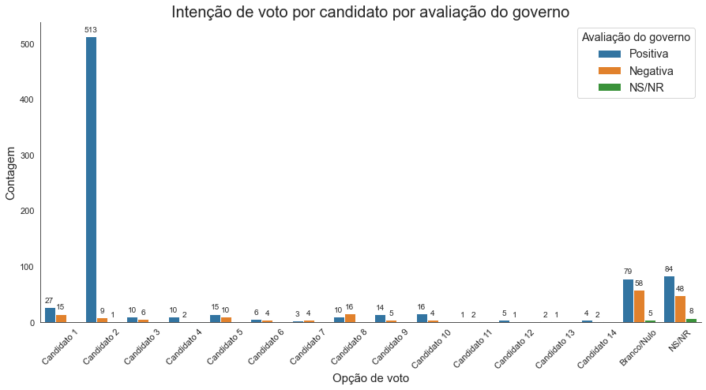

```python
# estilo white do seaborn
sns.set_style('white')

# Ordem alfabética
ordem = ["Candidato 1", "Candidato 2", "Candidato 3", "Candidato 4", "Candidato 5", "Candidato 6", "Candidato 7", "Candidato 8",
"Candidato 9", "Candidato 10", "Candidato 11", "Candidato 12", "Candidato 13", "Candidato 14", "Branco/Nulo", "NS/NR"]

plt.figure(figsize = (15,7))
ax = sns.countplot(x = "voto1", data = df, hue = 'aval_gov_resumido', order = ordem)
title = ax.axes.set_title('Intenção de voto por candidato por avaliação do governo',fontsize = 20) # Título e tamanho
x_labels = ax.set_xticklabels(rotation=45, labels = ax.get_xticklabels()) # possível utilizar também: labels = df['voto1'].unique()
x_axis_name = ax.set_xlabel('Opção de voto', fontsize=15) # Nome eixo x e tamanho
y_axis_name = ax.set_ylabel('Contagem', fontsize=15) # Nome eixo y e tamanho
axis_num_size = ax.tick_params(labelsize=11) # ajuste do tamanho dos valores dos eixos
ax.legend(title = 'Avaliação do governo', loc = 0, fontsize = 'x-large', title_fontsize = 'x-large')

# O código abaixo para colocar os números nas barras foi retirado e adaptado de:
#https://medium.com/swlh/quick-guide-to-labelling-data-for-common-seaborn-plots-736e10bf14a9

for p in ax.patches:
    # determina a altura de cada barra
    altura = p.get_height()
    # adiciona o texto em cada barra
    numeros = ax.text(x = p.get_x()+(p.get_width()/2), # posição x de cada número. ficará no centro.
    y = altura+8, # posição y do número, 8 unidades acima da barra
    s = '{:.0f}'.format(altura), # formatação para número inteiro
    ha = 'center') # alinhamento horizontal no centro
    #p.set_width(0.35)

import warnings

#ignore by message
warnings.filterwarnings("ignore", message="posx and posy should be finite values")

sns.despine() # remover o contorno

#Código para ignorar os avisos do plot voto1 x aval_gov_resumido. O plot funciona normalmente, porém quando encontra
# uma categoria NS/NR que é igual a zero, dá o aviso

#Fonte: https://stackoverflow.com/questions/9031783/hide-all-warnings-in-ipython

from IPython.display import HTML
HTML('''<script>
code_show_err=false;
function code_toggle_err() {
 if (code_show_err){
 $('div.output_stderr').hide();
 } else {
 $('div.output_stderr').show();
 }
 code_show_err = !code_show_err
}
$( document ).ready(code_toggle_err);
</script>
<a href="javascript:code_toggle_err()">Desligar avisos do plot</a>.''')
```

## 5.2. sexo x voto1

```python
tabcont_2var(df['voto1'], df['sexo'])
```

```
Valores absolutos:

| voto1        |   Feminino |   Masculino |   All |
|:-------------|-----------:|------------:|------:|
| Branco/Nulo  |         72 |          70 |   142 |
| Candidato 1  |         11 |          31 |    42 |
| Candidato 10 |         14 |           6 |    20 |
| Candidato 11 |          1 |           2 |     3 |
| Candidato 12 |          3 |           3 |     6 |
| Candidato 13 |          2 |           1 |     3 |
| Candidato 14 |          6 |           0 |     6 |
| Candidato 2  |        295 |         228 |   523 |
| Candidato 3  |          9 |           7 |    16 |
| Candidato 4  |          4 |           8 |    12 |
| Candidato 5  |         14 |          11 |    25 |
| Candidato 6  |          7 |           3 |    10 |
| Candidato 7  |          3 |           4 |     7 |
| Candidato 8  |         14 |          12 |    26 |
| Candidato 9  |          7 |          12 |    19 |
| NS/NR        |         83 |          57 |   140 |
| All          |        545 |         455 |  1000 |

Porcentagem na linha:

| voto1        |   Feminino |   Masculino |   All |
|:-------------|-----------:|------------:|------:|
| Branco/Nulo  |       0.51 |        0.49 |     1 |
| Candidato 1  |       0.26 |        0.74 |     1 |
| Candidato 10 |       0.7  |        0.3  |     1 |
| Candidato 11 |       0.33 |        0.67 |     1 |
| Candidato 12 |       0.5  |        0.5  |     1 |
| Candidato 13 |       0.67 |        0.33 |     1 |
| Candidato 14 |       1    |        0    |     1 |
| Candidato 2  |       0.56 |        0.44 |     1 |
| Candidato 3  |       0.56 |        0.44 |     1 |
| Candidato 4  |       0.33 |        0.67 |     1 |
| Candidato 5  |       0.56 |        0.44 |     1 |
| Candidato 6  |       0.7  |        0.3  |     1 |
| Candidato 7  |       0.43 |        0.57 |     1 |
| Candidato 8  |       0.54 |        0.46 |     1 |
```

[output cut: 10 more lines]

```
| Candidato 10 |       0.03 |        0.01 |  0.02 |
| Candidato 11 |       0    |        0    |  0    |
| Candidato 12 |       0.01 |        0.01 |  0.01 |
| Candidato 13 |       0    |        0    |  0    |
| Candidato 14 |       0.01 |        0    |  0.01 |
| Candidato 2  |       0.54 |        0.5  |  0.52 |
| Candidato 3  |       0.02 |        0.02 |  0.02 |
| Candidato 4  |       0.01 |        0.02 |  0.01 |
| Candidato 5  |       0.03 |        0.02 |  0.02 |
| Candidato 6  |       0.01 |        0.01 |  0.01 |
| Candidato 7  |       0.01 |        0.01 |  0.01 |
| Candidato 8  |       0.03 |        0.03 |  0.03 |
| Candidato 9  |       0.01 |        0.03 |  0.02 |
| NS/NR        |       0.15 |        0.13 |  0.14 |
| All          |       1    |        1    |  1    |
```

Pode-se observar que:

- As mulheres, assim como os homens, preferem o candidato 2, porém os homens também se simpatizam pelo candidato 1, que teve 31 votos masculinos contra 11 femininos;
- Homens e mulheres tendem, ao redor dos 15% a, ou votarem em branco ou a não saberem em quem votariam;
- Nesta base, homens e mulheres são semelhantes na questão de voto. As mulheres tendem a saber menos o voto que os homens, mas a diferença não é significativa

## 5.3. idade (categorizada) x voto1

Categorizando a variável idade em 4 categorias

```python
df['idade_cat'] = pd.qcut(df['idade'], q=4, precision=2)
```

```python
tabcont_2var(df['voto1'], df['idade_cat'])
```

```
Valores absolutos:

| voto1        |   (16.99, 30.0] |   (30.0, 43.0] |   (43.0, 58.0] |   (58.0, 86.0] |   All |
|:-------------|----------------:|---------------:|---------------:|---------------:|------:|
| Branco/Nulo  |              34 |             37 |             37 |             34 |   142 |
| Candidato 1  |               5 |             13 |              9 |             15 |    42 |
| Candidato 10 |               8 |              7 |              3 |              2 |    20 |
| Candidato 11 |               1 |              0 |              2 |              0 |     3 |
| Candidato 12 |               0 |              2 |              4 |              0 |     6 |
| Candidato 13 |               1 |              0 |              1 |              1 |     3 |
| Candidato 14 |               4 |              1 |              1 |              0 |     6 |
| Candidato 2  |             127 |            124 |            130 |            142 |   523 |
| Candidato 3  |               6 |              3 |              2 |              5 |    16 |
| Candidato 4  |               0 |              1 |              7 |              4 |    12 |
| Candidato 5  |              12 |              9 |              4 |              0 |    25 |
| Candidato 6  |               4 |              4 |              1 |              1 |    10 |
| Candidato 7  |               1 |              2 |              1 |              3 |     7 |
| Candidato 8  |               8 |              6 |              7 |              5 |    26 |
| Candidato 9  |               6 |              7 |              4 |              2 |    19 |
| NS/NR        |              39 |             32 |             35 |             34 |   140 |
| All          |             256 |            248 |            248 |            248 |  1000 |

Porcentagem na linha:

| voto1        |   (16.99, 30.0] |   (30.0, 43.0] |   (43.0, 58.0] |   (58.0, 86.0] |   All |
|:-------------|----------------:|---------------:|---------------:|---------------:|------:|
| Branco/Nulo  |            0.24 |           0.26 |           0.26 |           0.24 |     1 |
| Candidato 1  |            0.12 |           0.31 |           0.21 |           0.36 |     1 |
| Candidato 10 |            0.4  |           0.35 |           0.15 |           0.1  |     1 |
| Candidato 11 |            0.33 |           0    |           0.67 |           0    |     1 |
| Candidato 12 |            0    |           0.33 |           0.67 |           0    |     1 |
| Candidato 13 |            0.33 |           0    |           0.33 |           0.33 |     1 |
| Candidato 14 |            0.67 |           0.17 |           0.17 |           0    |     1 |
| Candidato 2  |            0.24 |           0.24 |           0.25 |           0.27 |     1 |
| Candidato 3  |            0.38 |           0.19 |           0.12 |           0.31 |     1 |
| Candidato 4  |            0    |           0.08 |           0.58 |           0.33 |     1 |
| Candidato 5  |            0.48 |           0.36 |           0.16 |           0    |     1 |
| Candidato 6  |            0.4  |           0.4  |           0.1  |           0.1  |     1 |
| Candidato 7  |            0.14 |           0.29 |           0.14 |           0.43 |     1 |
| Candidato 8  |            0.31 |           0.23 |           0.27 |           0.19 |     1 |
```

[output cut: 10 more lines]

```
| Candidato 10 |            0.03 |           0.03 |           0.01 |           0.01 |  0.02 |
| Candidato 11 |            0    |           0    |           0.01 |           0    |  0    |
| Candidato 12 |            0    |           0.01 |           0.02 |           0    |  0.01 |
| Candidato 13 |            0    |           0    |           0    |           0    |  0    |
| Candidato 14 |            0.02 |           0    |           0    |           0    |  0.01 |
| Candidato 2  |            0.5  |           0.5  |           0.52 |           0.57 |  0.52 |
| Candidato 3  |            0.02 |           0.01 |           0.01 |           0.02 |  0.02 |
| Candidato 4  |            0    |           0    |           0.03 |           0.02 |  0.01 |
| Candidato 5  |            0.05 |           0.04 |           0.02 |           0    |  0.02 |
| Candidato 6  |            0.02 |           0.02 |           0    |           0    |  0.01 |
| Candidato 7  |            0    |           0.01 |           0    |           0.01 |  0.01 |
| Candidato 8  |            0.03 |           0.02 |           0.03 |           0.02 |  0.03 |
| Candidato 9  |            0.02 |           0.03 |           0.02 |           0.01 |  0.02 |
| NS/NR        |            0.15 |           0.13 |           0.14 |           0.14 |  0.14 |
| All          |            1    |           1    |           1    |           1    |  1    |
```

Observa-se, então, que:

- Idade não aparenta ser um divisor de águas para a questão da intenção de voto, as proporções entre os 4 grupos são parecidas em números absolutos e em porcentagem
- Os 4 grupos de idade votam de forma semelhante no candidato 2
- Os 4 grupos de idade também apresentam proporções semelhantes de voto em branco e NS/NR

## 5.4. rendaf x voto1

A variável rendaf gera uma quebra de layout na função tabcont_2var pois suas categorias têm nomes grandes. Para endereçar o problema, vou transformar as categorias de rendaf em uma variável ordinal e deixar registrado as categorias para consulta, elas são:

1. Até R\$ 1.045,00 (até 1 SM)
2. De R\$ 1.046,00 a R\\$ 2.090,00 (+ de 1SM até 2 SM)
3. De R\$ 2.091,00 a R\\$ 3.135,00 (+ de 2SM até 3 SM)
4. De R\$ 3.136,00 a R\\$ 5.225,00 (+ de 3SM até 5 SM)
5. De R\$ 5.226,00 a R\\$ 10.450,00 (+ de 5SM até 10 SM)
6. De R\$ 10.451,00 a R\\$ 15.675,00 (+ de 10SM até 15 SM)
7. De R\$ 15.676,00 a R\\$ 20.900,00 (+ de 15SM até 20 SM)
8. Mais de R\$ 20.900,00 (+ de 20 SM)

```python
print(df['rendaf'].unique())
print(len(df['rendaf'].unique()))
```

```
['De R$ 2.091,00 a R$ 3.135,00 (+ de 2SM até 3 SM)'
 'De R$ 5.226,00 a R$ 10.450,00 (+ de 5SM até 10 SM)'
 'De R$ 3.136,00 a R$ 5.225,00 (+ de 3SM até 5 SM)'
 'De R$ 1.046,00 a R$ 2.090,00 (+ de 1SM até 2 SM)'
 'Até R$ 1.045,00 (até 1 SM)'
 'De R$ 15.676,00 a R$ 20.900,00 (+ de 15SM até 20 SM)'
 'De R$ 10.451,00 a R$ 15.675,00 (+ de 10SM até 15 SM)'
 'Mais de R$ 20.900,00 (+ de 20 SM)']
8
```

```python
df['rendaf_ordinal'] = df['rendaf']
df['rendaf_ordinal'] = df['rendaf_ordinal'].replace(['Até R$ 1.045,00 (até 1 SM)',
                                                     'De R$ 1.046,00 a R$ 2.090,00 (+ de 1SM até 2 SM)',
                                                     'De R$ 2.091,00 a R$ 3.135,00 (+ de 2SM até 3 SM)',
                                                    'De R$ 3.136,00 a R$ 5.225,00 (+ de 3SM até 5 SM)',
                                                    'De R$ 5.226,00 a R$ 10.450,00 (+ de 5SM até 10 SM)',
                                                    'De R$ 10.451,00 a R$ 15.675,00 (+ de 10SM até 15 SM)',
                                                    'De R$ 15.676,00 a R$ 20.900,00 (+ de 15SM até 20 SM)',
                                                    'Mais de R$ 20.900,00 (+ de 20 SM)'],
                                                    [1, 2, 3, 4, 5, 6, 7, 8])
```

```python
tabcont_2var(df['voto1'], df['rendaf_ordinal'])
```

```
Valores absolutos:

| voto1        |   1 |   2 |   3 |   4 |   5 |   6 |   7 |   8 |   All |
|:-------------|----:|----:|----:|----:|----:|----:|----:|----:|------:|
| Branco/Nulo  |  38 |  36 |  33 |  19 |  10 |   5 |   1 |   0 |   142 |
| Candidato 1  |   4 |  12 |  10 |   7 |   7 |   1 |   0 |   1 |    42 |
| Candidato 10 |   5 |   6 |   3 |   3 |   1 |   2 |   0 |   0 |    20 |
| Candidato 11 |   0 |   3 |   0 |   0 |   0 |   0 |   0 |   0 |     3 |
| Candidato 12 |   2 |   1 |   1 |   0 |   2 |   0 |   0 |   0 |     6 |
| Candidato 13 |   1 |   1 |   1 |   0 |   0 |   0 |   0 |   0 |     3 |
| Candidato 14 |   1 |   2 |   2 |   0 |   1 |   0 |   0 |   0 |     6 |
| Candidato 2  | 106 | 138 | 100 |  96 |  56 |  13 |  11 |   3 |   523 |
| Candidato 3  |   2 |   5 |   5 |   2 |   2 |   0 |   0 |   0 |    16 |
| Candidato 4  |   1 |   4 |   2 |   1 |   3 |   1 |   0 |   0 |    12 |
| Candidato 5  |   1 |   3 |   7 |   9 |   3 |   2 |   0 |   0 |    25 |
| Candidato 6  |   2 |   3 |   4 |   1 |   0 |   0 |   0 |   0 |    10 |
| Candidato 7  |   1 |   3 |   1 |   0 |   1 |   0 |   1 |   0 |     7 |
| Candidato 8  |   2 |   2 |   7 |   6 |   7 |   0 |   1 |   1 |    26 |
| Candidato 9  |   6 |   5 |   3 |   3 |   1 |   1 |   0 |   0 |    19 |
| NS/NR        |  33 |  22 |  31 |  30 |  16 |   3 |   3 |   2 |   140 |
| All          | 205 | 246 | 210 | 177 | 110 |  28 |  17 |   7 |  1000 |

Porcentagem na linha:

| voto1        |    1 |    2 |    3 |    4 |    5 |    6 |    7 |    8 |   All |
|:-------------|-----:|-----:|-----:|-----:|-----:|-----:|-----:|-----:|------:|
| Branco/Nulo  | 0.27 | 0.25 | 0.23 | 0.13 | 0.07 | 0.04 | 0.01 | 0    |     1 |
| Candidato 1  | 0.1  | 0.29 | 0.24 | 0.17 | 0.17 | 0.02 | 0    | 0.02 |     1 |
| Candidato 10 | 0.25 | 0.3  | 0.15 | 0.15 | 0.05 | 0.1  | 0    | 0    |     1 |
| Candidato 11 | 0    | 1    | 0    | 0    | 0    | 0    | 0    | 0    |     1 |
| Candidato 12 | 0.33 | 0.17 | 0.17 | 0    | 0.33 | 0    | 0    | 0    |     1 |
| Candidato 13 | 0.33 | 0.33 | 0.33 | 0    | 0    | 0    | 0    | 0    |     1 |
| Candidato 14 | 0.17 | 0.33 | 0.33 | 0    | 0.17 | 0    | 0    | 0    |     1 |
| Candidato 2  | 0.2  | 0.26 | 0.19 | 0.18 | 0.11 | 0.02 | 0.02 | 0.01 |     1 |
| Candidato 3  | 0.12 | 0.31 | 0.31 | 0.12 | 0.12 | 0    | 0    | 0    |     1 |
| Candidato 4  | 0.08 | 0.33 | 0.17 | 0.08 | 0.25 | 0.08 | 0    | 0    |     1 |
| Candidato 5  | 0.04 | 0.12 | 0.28 | 0.36 | 0.12 | 0.08 | 0    | 0    |     1 |
| Candidato 6  | 0.2  | 0.3  | 0.4  | 0.1  | 0    | 0    | 0    | 0    |     1 |
| Candidato 7  | 0.14 | 0.43 | 0.14 | 0    | 0.14 | 0    | 0.14 | 0    |     1 |
| Candidato 8  | 0.08 | 0.08 | 0.27 | 0.23 | 0.27 | 0    | 0.04 | 0.04 |     1 |
```

[output cut: 10 more lines]

```
| Candidato 10 | 0.02 | 0.02 | 0.01 | 0.02 | 0.01 | 0.07 | 0    | 0    |  0.02 |
| Candidato 11 | 0    | 0.01 | 0    | 0    | 0    | 0    | 0    | 0    |  0    |
| Candidato 12 | 0.01 | 0    | 0    | 0    | 0.02 | 0    | 0    | 0    |  0.01 |
| Candidato 13 | 0    | 0    | 0    | 0    | 0    | 0    | 0    | 0    |  0    |
| Candidato 14 | 0    | 0.01 | 0.01 | 0    | 0.01 | 0    | 0    | 0    |  0.01 |
| Candidato 2  | 0.52 | 0.56 | 0.48 | 0.54 | 0.51 | 0.46 | 0.65 | 0.43 |  0.52 |
| Candidato 3  | 0.01 | 0.02 | 0.02 | 0.01 | 0.02 | 0    | 0    | 0    |  0.02 |
| Candidato 4  | 0    | 0.02 | 0.01 | 0.01 | 0.03 | 0.04 | 0    | 0    |  0.01 |
| Candidato 5  | 0    | 0.01 | 0.03 | 0.05 | 0.03 | 0.07 | 0    | 0    |  0.02 |
| Candidato 6  | 0.01 | 0.01 | 0.02 | 0.01 | 0    | 0    | 0    | 0    |  0.01 |
| Candidato 7  | 0    | 0.01 | 0    | 0    | 0.01 | 0    | 0.06 | 0    |  0.01 |
| Candidato 8  | 0.01 | 0.01 | 0.03 | 0.03 | 0.06 | 0    | 0.06 | 0.14 |  0.03 |
| Candidato 9  | 0.03 | 0.02 | 0.01 | 0.02 | 0.01 | 0.04 | 0    | 0    |  0.02 |
| NS/NR        | 0.16 | 0.09 | 0.15 | 0.17 | 0.15 | 0.11 | 0.18 | 0.29 |  0.14 |
| All          | 1    | 1    | 1    | 1    | 1    | 1    | 1    | 1    |  1    |
```

Observa-se que:

- 94,8% da base ganha até 10 salários mínimos (categorias de 1 a 5) e estes têm preferência pelo candidato 2, em torno dos 50%, em sua maioria e, em média, 30% destes eleitores, anulariam ou não sabem do seu voto
- A classe 6, de 10 a 15SM, mantém a mesma tendência que as classes de 1 a 5, tanto de voto no candidato 2 quanto na anulação/NS
- As classe 7 tem uma preferência pelo candidato 2 ainda maior que as outras, de 65%
- A classe 8 possui uma amostragem muito baixa, apenas 7 respondentes, é complicado tirar conclusões sobre ela
- A classe que mais anula ou não sabe o voto é a com menor renda, que recebe até 1 SM, com 35%

## 5.5. esc x voto1

Assim como a variável rendaf, a variável esc também gera uma quebra de layout na função tabcont_2var. Para corrigir isso, vou transformar as escolaridades também uma variável ordinal e deixar registrado as categorias para consulta, elas são:

1. Sem instrução e menos de 1 ano de estudo
2. Ensino fundamental incompleto
3. Ensino fundamental completo
4. Ensino médio incompleto
5. Ensino médio completo
6. Ensino superior incompleto
7. Ensino superior completo

```python
print(df['esc'].unique())
print(len(df['esc'].unique()))
```

```
['Ensino médio completo' 'Ensino fundamental incompleto'
 'Ensino superior incompleto' 'Ensino superior completo'
 'Sem instrução e menos de 1 ano de estudo' 'Ensino médio incompleto'
 'Ensino fundamental completo']
7
```

```python
df['esc_ordinal'] = df['esc']
df['esc_ordinal'] = df['esc_ordinal'].replace(['Sem instrução e menos de 1 ano de estudo',
                                             'Ensino fundamental incompleto',
                                            'Ensino fundamental completo',
                                            'Ensino médio incompleto',
                                            'Ensino médio completo',
                                            'Ensino superior incompleto',
                                            'Ensino superior completo'],
                                            [1, 2, 3, 4, 5, 6, 7])
```

```python
tabcont_2var(df['voto1'], df['esc_ordinal'])
```

```
Valores absolutos:

| voto1        |   1 |   2 |   3 |   4 |   5 |   6 |   7 |   All |
|:-------------|----:|----:|----:|----:|----:|----:|----:|------:|
| Branco/Nulo  |   1 |  23 |  11 |  14 |  59 |  15 |  19 |   142 |
| Candidato 1  |   0 |  14 |   2 |   2 |  10 |   4 |  10 |    42 |
| Candidato 10 |   1 |   2 |   1 |   3 |   9 |   2 |   2 |    20 |
| Candidato 11 |   0 |   1 |   0 |   0 |   1 |   0 |   1 |     3 |
| Candidato 12 |   0 |   2 |   0 |   1 |   0 |   1 |   2 |     6 |
| Candidato 13 |   0 |   0 |   1 |   0 |   2 |   0 |   0 |     3 |
| Candidato 14 |   0 |   0 |   0 |   3 |   1 |   0 |   2 |     6 |
| Candidato 2  |  10 | 105 |  50 |  43 | 177 |  45 |  93 |   523 |
| Candidato 3  |   0 |   4 |   1 |   0 |   5 |   3 |   3 |    16 |
| Candidato 4  |   0 |   3 |   0 |   0 |   3 |   2 |   4 |    12 |
| Candidato 5  |   0 |   0 |   0 |   2 |   5 |   8 |  10 |    25 |
| Candidato 6  |   0 |   1 |   0 |   2 |   4 |   1 |   2 |    10 |
| Candidato 7  |   0 |   2 |   0 |   1 |   1 |   2 |   1 |     7 |
| Candidato 8  |   0 |   1 |   2 |   1 |   6 |   5 |  11 |    26 |
| Candidato 9  |   0 |   3 |   3 |   3 |   5 |   3 |   2 |    19 |
| NS/NR        |   5 |  23 |  13 |  14 |  38 |  14 |  33 |   140 |
| All          |  17 | 184 |  84 |  89 | 326 | 105 | 195 |  1000 |

Porcentagem na linha:

| voto1        |    1 |    2 |    3 |    4 |    5 |    6 |    7 |   All |
|:-------------|-----:|-----:|-----:|-----:|-----:|-----:|-----:|------:|
| Branco/Nulo  | 0.01 | 0.16 | 0.08 | 0.1  | 0.42 | 0.11 | 0.13 |     1 |
| Candidato 1  | 0    | 0.33 | 0.05 | 0.05 | 0.24 | 0.1  | 0.24 |     1 |
| Candidato 10 | 0.05 | 0.1  | 0.05 | 0.15 | 0.45 | 0.1  | 0.1  |     1 |
| Candidato 11 | 0    | 0.33 | 0    | 0    | 0.33 | 0    | 0.33 |     1 |
| Candidato 12 | 0    | 0.33 | 0    | 0.17 | 0    | 0.17 | 0.33 |     1 |
| Candidato 13 | 0    | 0    | 0.33 | 0    | 0.67 | 0    | 0    |     1 |
| Candidato 14 | 0    | 0    | 0    | 0.5  | 0.17 | 0    | 0.33 |     1 |
| Candidato 2  | 0.02 | 0.2  | 0.1  | 0.08 | 0.34 | 0.09 | 0.18 |     1 |
| Candidato 3  | 0    | 0.25 | 0.06 | 0    | 0.31 | 0.19 | 0.19 |     1 |
| Candidato 4  | 0    | 0.25 | 0    | 0    | 0.25 | 0.17 | 0.33 |     1 |
| Candidato 5  | 0    | 0    | 0    | 0.08 | 0.2  | 0.32 | 0.4  |     1 |
| Candidato 6  | 0    | 0.1  | 0    | 0.2  | 0.4  | 0.1  | 0.2  |     1 |
| Candidato 7  | 0    | 0.29 | 0    | 0.14 | 0.14 | 0.29 | 0.14 |     1 |
| Candidato 8  | 0    | 0.04 | 0.08 | 0.04 | 0.23 | 0.19 | 0.42 |     1 |
```

[output cut: 10 more lines]

```
| Candidato 10 | 0.06 | 0.01 | 0.01 | 0.03 | 0.03 | 0.02 | 0.01 |  0.02 |
| Candidato 11 | 0    | 0.01 | 0    | 0    | 0    | 0    | 0.01 |  0    |
| Candidato 12 | 0    | 0.01 | 0    | 0.01 | 0    | 0.01 | 0.01 |  0.01 |
| Candidato 13 | 0    | 0    | 0.01 | 0    | 0.01 | 0    | 0    |  0    |
| Candidato 14 | 0    | 0    | 0    | 0.03 | 0    | 0    | 0.01 |  0.01 |
| Candidato 2  | 0.59 | 0.57 | 0.6  | 0.48 | 0.54 | 0.43 | 0.48 |  0.52 |
| Candidato 3  | 0    | 0.02 | 0.01 | 0    | 0.02 | 0.03 | 0.02 |  0.02 |
| Candidato 4  | 0    | 0.02 | 0    | 0    | 0.01 | 0.02 | 0.02 |  0.01 |
| Candidato 5  | 0    | 0    | 0    | 0.02 | 0.02 | 0.08 | 0.05 |  0.02 |
| Candidato 6  | 0    | 0.01 | 0    | 0.02 | 0.01 | 0.01 | 0.01 |  0.01 |
| Candidato 7  | 0    | 0.01 | 0    | 0.01 | 0    | 0.02 | 0.01 |  0.01 |
| Candidato 8  | 0    | 0.01 | 0.02 | 0.01 | 0.02 | 0.05 | 0.06 |  0.03 |
| Candidato 9  | 0    | 0.02 | 0.04 | 0.03 | 0.02 | 0.03 | 0.01 |  0.02 |
| NS/NR        | 0.29 | 0.12 | 0.15 | 0.16 | 0.12 | 0.13 | 0.17 |  0.14 |
| All          | 1    | 1    | 1    | 1    | 1    | 1    | 1    |  1    |
```